# act_report

## Report: act_report

- Create a **250-word-minimum written report** called "act_report.pdf" or "act_report.html" that communicates the insights and displays the visualization(s) produced from your wrangled data. This is to be framed as an external document, like a blog post or magazine article, for example.

After data wrangling and analysis, several interesting insights can be made. The most popular dog names in the dataset were Tucker and Cooper with each name occuring a total of 10 times each. The names Charlie, Penny, Oliver, Lucy were also highly popular and were all mentioned 9 times each. The top five dog breeds in colunmn p1 were Golden_Retriever, Labrador_Retriever, Pembroke, Chihuahua, and Pug occuring 150, 96, 88, 81, and 57 times respectively. The date that the most images of dogs were tweeted was 29 Nov 2015. There was a total of 22 dog images tweeted on that day. The horizontal bar chart displays the top 10 dates that the highest number of dog images were tweeted. All of these dates occured in November and December 2015.

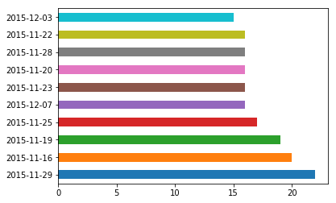

The tweet that had the highest retweet count was retweeted a total of 71758 times. The same tweet also had the highest favorite count for a total number of 146559. Although Golden_retriever was the most common dog breed tweeted, the tweet that had both the highest favorite count and retweet count was actually of a Laborador retriever. Since this tweet had the both the highest favorite count and retweet count, a further analysis was conducted to determine if there was a correlation between the favorite count and the retweet count. A scatter plot visualization depicts a linear correlation between the favorite count and retweet count. Furthermore, the result of a Pearson Correlation test conducted was 0.867. Since the Pearson correlation value is higher than 0.7, this indicates that there is a high linear correlation between the favorite count and the retweet count.

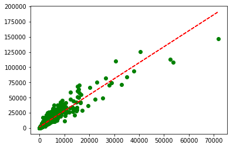